# Лабораторная работа 5

Модель эпидемии (SIR)

Туем Г.

Российский университет дружбы народов, Москва, Россия

# Информация

## Докладчик

- Туем Гислен
- Студент
- НКНбд-01-22
- Российский университет дружбы народов
- 1032225069@pfur.ru

[figure not shown]

# Цели и задачи

Построить модель SIR в xcos и в OpenModelicaв xcos.

1. Реализовать модель SIR в в xcos;
2. Реализовать модель SIR с помощью блока Modelica в в xcos;
3. Реализовать модель SIR в OpenModelica;
4. Реализовать модель SIR с учётом процесса рождения / гибели особей в xcos (в том числе и с использованием блока Modelica), а также в OpenModelica;
5. Построить графики эпидемического порога при различных значениях параметров модели(в частности изменяя параметр μ); Сделать анализ полученных графиков в зависимости от выбранных значений параметров модели.

# Выполнение лабораторной работы

# Реализация модели в xcos

Зафиксируем начальные данные: β = 1, ν = 0, 3, s(0) = 0, 999, i(0) = 0, 001, r(0) = 0.

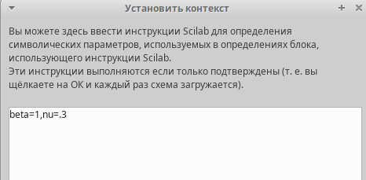

задать переменные окружения в xcos

# Реализация модели в xcos

[figure not shown]

Модель SIR в xcos

# Реализация модели в xcos

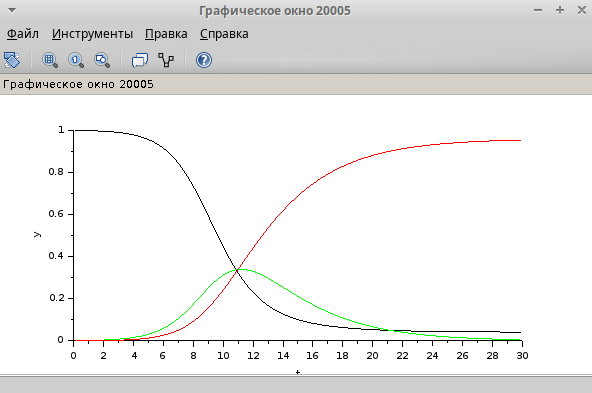

Эпидемический порог модели SIR

# Реализация модели с помощью блока Modelica в xcos

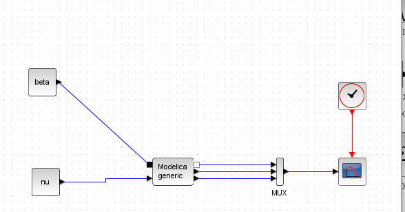

Модель SIR в xcos с применением блока Modelica

## Код на языке Modelica

```
class generic
////automatically generated ////
    //input variables
    Real beta,nu;
    //output variables (комментируем, т.к.
    // начальные значения задаем в самом блоке):
    // Real s,i,r;
////do not modif above this line ////
    // Начальные значения:
    Real s(start=.999), i(start=.001), r(start=.0);
    // модель SIR:
equation
    der(s)=-beta*s*i;
    der(i)=beta*s*i-nu*i;
    der(r)=nu*i;
end generic;
```

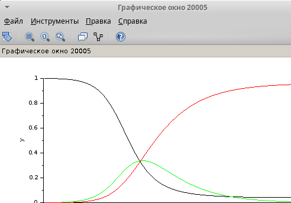

Результат моделирования

# Упражнение

Результат модель SIR в OpenModelica

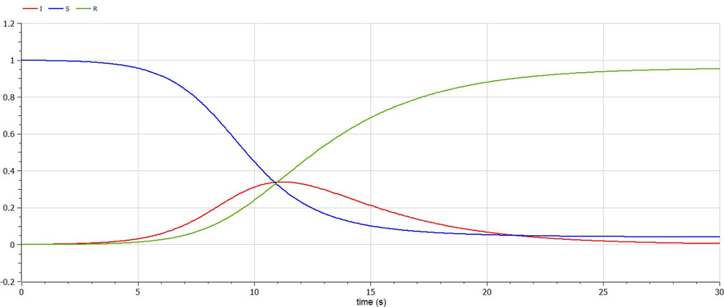

Результат модель SIR в OpenModelica

# Задание для самостоятельного выполнения

Предположим, что учитываются демографические процессы, в частности, что смертность в популяции полностью уравновешивает рождаемость, а все рожденные индивидуу- мы появляются на свет абсолютно здоровыми. Тогда получим следующую систему уравнений :

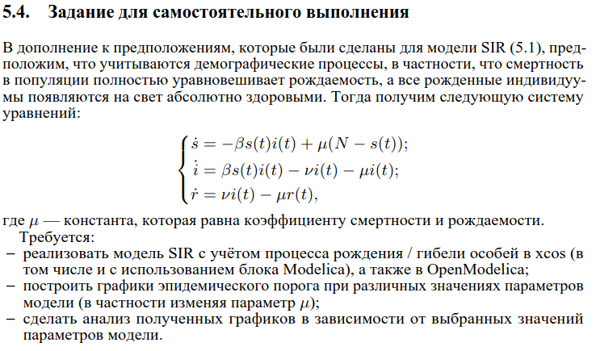

# Задание для самостоятельного выполнения

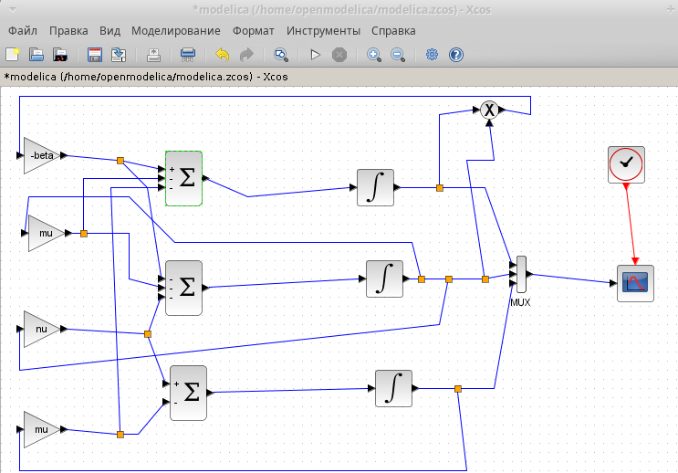

# Задание для самостоятельного выполнения

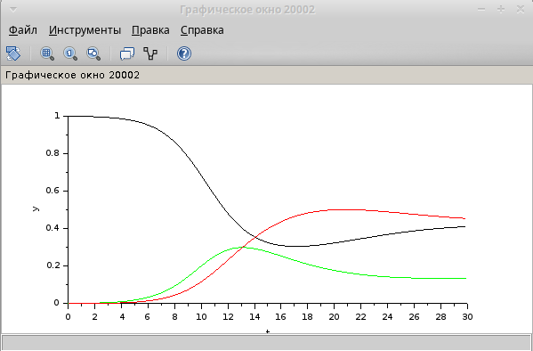

# Задание для самостоятельного выполнения

Теперь реализуем модель SIR с учетом демографических процессов в xcos с помощью блоков Modelica

[figure not shown]

# Задание для самостоятельного выполнения

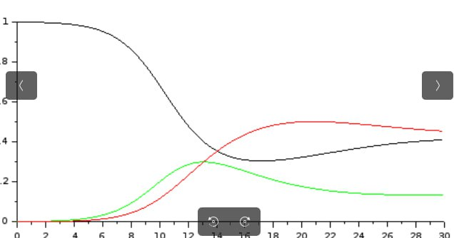

# Задание для самостоятельного выполнения

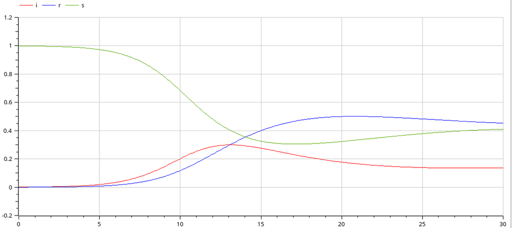

# Задание для самостоятельного выполнения

Теперь построим графики при разных значениях параметров.

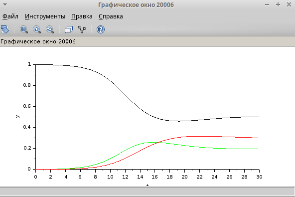

β=1, ν=0.3,μ=0.2

# Задание для самостоятельного выполнения

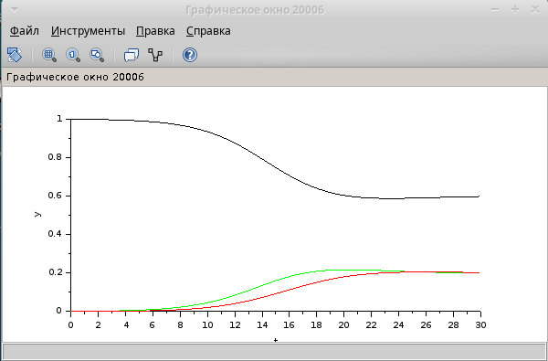

β=1, ν=0.3,μ=0.3

# Задание для самостоятельного выполнения

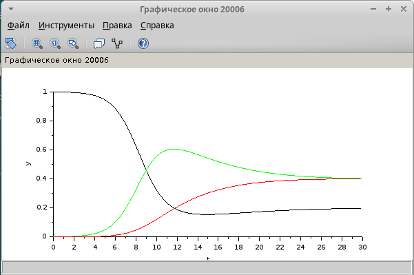

β=1, ν=0.1,μ=0.1